**Author**: Imene DERRAR · **Supervisor**: Dr. Abdelillah OTMANE CHERIF  
**Institutions**: NHSM — National Higher School of Mathematics · IHFR — Institut Hydrométéorologique de Formation et de Recherche  
**Academic year**: 2025–2026  
**Project**: Final-year engineering thesis in Applied Mathematics — Specialization: Statistics, Econometrics and Actuarial Science — Drought modelling and probabilistic forecasting for the Chélif basin

# Notebook E.3 --- Preprocessing pipeline and nine-station selection

**Thesis support.** Chapter 3 (Data Engineering and Index Construction), §3.5--§3.7

**Purpose.** Applies the four-stage preprocessing pipeline (cleaning, sentinel-value handling, conflict resolution, controlled three-month linear interpolation) and the C1/C2/C3 station-selection filter that reduces the 32-station master panel to the nine stations retained for the SPI track over 1990--2015.

**Main inputs.** Master precipitation panel from notebook E.2.

**Main outputs.** SPI-ready dataset (9 retained stations, 2,808 station-month records, gap-free at the three-month interpolation ceiling); station-eligibility table referenced as Table 3.6 in the thesis.

**Dependencies.** Requires notebook E.2 to have been run first.

**Execution notes.** All code cells in this notebook have been executed and their outputs (figures, tables, diagnostics) are saved inline. A re-run from a clean kernel should reproduce these outputs given the same input data, with the caveats listed in Appendix B of the thesis (reproducibility and computational environment).

# notebook E.3 — Data Preprocessing and Station Selection

**Thesis:** Drought Modeling and Probabilistic Forecasting in the Chélif Basin (Algeria) **Inputs:** outputs of notebook E.2 (data audit and structuring) **Outputs:** SPI-ready precipitation panel with controlled interpolation and full provenance tracking

## Purpose and scope

This notebook transforms the raw, grid-expanded precipitation dataset produced by notebook E.2 into a **controlled, quality-assured precipitation panel** suitable for direct input to the SPI Gamma distribution fitting procedure.

The operations performed here are, in order:

1. Restrict the dataset to the selected study period (1990–2015)
2. Replace physically impossible sentinel values (−999) with explicit NaN
3. Evaluate station reliability through completeness and gap analysis
4. Select stations under three conjunctive eligibility conditions (C1, C2, C3)
5. Apply controlled linear interpolation to fill gaps ≤ 3 consecutive months
6. Track every imputed value with an explicit provenance flag
7. Validate the final dataset and quantify the interpolation burden

**What this notebook does NOT do:**

- Compute SPI (that is the scope of notebook E.4)
- Impute missing values blindly or beyond the 3-month ceiling
- Remove stations without explicit, logged justification

Every transformation is deterministic, logged, and reproducible. All modified values are explicitly flagged, ensuring full transparency of preprocessing steps.

## Section 0 — Setup

All project paths are defined using `pathlib.Path` for cross-platform reproducibility. The output directory is created if it does not already exist.

```python
# ── Standard library ──────────────────────────────────────────────────────────
from pathlib import Path

# ── Third-party ───────────────────────────────────────────────────────────────
import numpy as np
import pandas as pd
import matplotlib.pyplot as plt
import matplotlib.patches as mpatches
import seaborn as sns

# ── Display settings ──────────────────────────────────────────────────────────
pd.set_option("display.max_columns", 20)
pd.set_option("display.max_rows", 60)
pd.set_option("display.float_format", "{:.4f}".format)
pd.set_option("display.width", 120)
sns.set_theme(style="whitegrid", palette="muted", font_scale=1.1)
plt.rcParams["figure.dpi"] = 120

# ── Notebook identity ─────────────────────────────────────────────────────────
NOTEBOOK_NAME = "01_data_preprocessing_and_station_selection"

# ── Project paths ─────────────────────────────────────────────────────────────
BASE_DIR     = Path(os.environ.get("CHELIF_BASE_DIR", Path.cwd()))
PREV_OUT_DIR = BASE_DIR / "03_outputs" / "00_data_audit_and_structuring"
OUTPUT_DIR   = BASE_DIR / "03_outputs" / NOTEBOOK_NAME
OUTPUT_DIR.mkdir(parents=True, exist_ok=True)

# ── Canonical column names ────────────────────────────────────────────────────
STATION_COL = "master_station_id"
DATE_COL    = "date"
PRECIP_COL  = "precip_mm"

# ── Eligibility thresholds ────────────────────────────────────────────────────
C1_THRESHOLD     = 0.90    # minimum pre-fill completeness
C2_MAX_GAP       = 3       # maximum fillable contiguous gap (months)
INTERP_MAX_GAP   = 3       # interpolation ceiling (must equal C2_MAX_GAP)
SENTINEL_VALUE   = -999.0  # missing-value code used in pluvio_chlef archive

print("Paths resolved:")
for label, path in [("Prev. outputs", PREV_OUT_DIR), ("This notebook outputs", OUTPUT_DIR)]:
    exists = "✓" if path.exists() else "✗  NOT FOUND — check project structure"
    print(f"  [{exists}]  {label}: {path}")
print()
print(f"Eligibility thresholds:  C1 ≥ {C1_THRESHOLD:.0%}  |  C2 max_gap ≤ {C2_MAX_GAP} months")
```

```
Paths resolved:
  [✓]  Prev. outputs: <project_root>\03_outputs\00_data_audit_and_structuring
  [✓]  This notebook outputs: <project_root>\03_outputs\01_data_preprocessing_and_station_selection

Eligibility thresholds:  C1 ≥ 90%  |  C2 max_gap ≤ 3 months
```

## Section 1 — Load Data

Two files are loaded from the outputs of notebook E.2:

| File | Content |
| --- | --- |
| `00_precipitation_full_grid.csv` | Full monthly grid with explicit NaN rows for all 32 stations, 1960–2019 |
| `selected_period.csv` | Machine-readable record of the selected study period (1990–2015) |

No data is modified at this stage.

```python
# ── Load full precipitation grid ──────────────────────────────────────────────
precip_raw = pd.read_csv(
    PREV_OUT_DIR / "00_precipitation_full_grid.csv",
    parse_dates=[DATE_COL],
)
print(f"Full grid loaded:  {precip_raw.shape[0]:,} rows × {precip_raw.shape[1]} columns")
print(f"Date range:        {precip_raw[DATE_COL].min().date()}  →  {precip_raw[DATE_COL].max().date()}")
print(f"Unique stations:   {precip_raw[STATION_COL].nunique()}")
print(f"Missing precip:    {precip_raw[PRECIP_COL].isna().sum():,}")
print()
precip_raw.head(4)
```

```
Full grid loaded:  14,380 rows × 6 columns
Date range:        1960-01-01  →  2019-12-01
Unique stations:   32
Missing precip:    669
```

|  | master_station_id | date | precip_mm | value_source | source_dataset | year |
| --- | --- | --- | --- | --- | --- | --- |
| 0 | M_011509__11509 | 1970-01-01 | 90.0000 | observed_new_fill_old_gap | merged_pair | 1970 |
| 1 | M_011509__11509 | 1970-02-01 | 82.9000 | observed_new_fill_old_gap | merged_pair | 1970 |
| 2 | M_011509__11509 | 1970-03-01 | 111.1000 | observed_new_fill_old_gap | merged_pair | 1970 |
| 3 | M_011509__11509 | 1970-04-01 | 13.3000 | observed_new_fill_old_gap | merged_pair | 1970 |

```python
# ── Load selected study period ────────────────────────────────────────────────
period = pd.read_csv(PREV_OUT_DIR / "selected_period.csv")
print("Selected period record:")
print(period.T.to_string())

STUDY_START = pd.Timestamp(period["selected_start"].iloc[0])
STUDY_END   = pd.Timestamp(period["selected_end"].iloc[0])
N_MONTHS    = int(period["length_months"].iloc[0])

print(f"\nStudy period:  {STUDY_START.date()}  →  {STUDY_END.date()}")
print(f"Expected months: {N_MONTHS}")
```

```
Selected period record:
                                                      0
selected_start                               1990-01-01
selected_end                                 2015-12-01
length_months                                       312
length_years                                         26
K_eligible_primary                                   15
secondary_start                              1991-01-01
secondary_end                                2010-12-01
selection_criterion  max_K_C1_C2_WMO25_drought_episodes

Study period:  1990-01-01  →  2015-12-01
Expected months: 312
```

## Section 2 — Sentinel Replacement, Period Restriction, and Grid Alignment

### 2.1 Sentinel value replacement

Inspection of the full grid reveals that the `pluvio_chlef` bulletin archive encoded missing observations as **−999.0** rather than as NaN. This is a documented archival convention, but −999 is a physically impossible precipitation value and must be replaced with explicit NaN **before** any other operation.

**Downstream consequence:** Feeding −999 into the Gamma distribution fitter would seriously bias the lower tail of the fitted distribution, producing grossly erroneous SPI values for affected stations and months.

### 2.2 Period restriction and canonical grid alignment

The dataset is filtered to [1990-01-01, 2015-12-01] as established in notebook E.2. However, the full-grid CSV was constructed per-station using `pd.date_range(first_obs, last_obs)` — meaning stations whose last observed date falls **before** 2015-12-01 have no rows (not NaN rows) for the trailing months of the study period.

A simple date-range filter therefore produces fewer than 312 rows for those stations, which would cause the V2 structural validation to fail and, more importantly, would cause the completeness ratio to be computed against the wrong denominator.

**Fix:** after slicing, a canonical scaffold of 312 monthly dates is constructed for every station and the observations are left-joined onto it. Months absent from the source archive appear as NaN rows — the correct and fully honest representation. This is a **structural alignment step, not imputation**.

```python
# ── 2.1  Replace -999 sentinel with NaN ───────────────────────────────────────
precip = precip_raw.copy()  # working copy — raw is never modified

n_sentinels = (precip[PRECIP_COL] == SENTINEL_VALUE).sum()
print(f"Sentinel values (-999) detected and replaced with NaN: {n_sentinels}")
print(f"  Affected stations: {precip.loc[precip[PRECIP_COL]==SENTINEL_VALUE, STATION_COL].unique().tolist()}")

precip.loc[precip[PRECIP_COL] == SENTINEL_VALUE, PRECIP_COL] = np.nan

# Verify no remaining physically impossible values
remaining_neg = (precip[PRECIP_COL] < 0).sum()
print(f"  Remaining negative values after sentinel removal: {remaining_neg}")
if remaining_neg > 0:
    print("  WARNING: non-sentinel negative values present — investigate before proceeding.")
```

```
Sentinel values (-999) detected and replaced with NaN: 22
  Affected stations: ['PLUVIO_012001_elabadia', 'PLUVIO_012201_larbat_ouled_fares', 'PLUVIO_012221_medjadja', 'PLUVIO_012225_oum_drou', 'PLUVIO_012308_ouled_ben_a']
  Remaining negative values after sentinel removal: 0
```

```python
# ── 2.2  Restrict to study period and enforce complete monthly grid ───────────
# The full-grid CSV from notebook E.2 spans each station's OWN observed range
# (pd.date_range from first to last observation). Stations whose last
# observed date falls before 2015-12-01 are therefore missing the trailing
# months entirely — they have NO rows, not NaN rows, for those months.
#
# Consequence: a simple date-range filter produces windows with fewer than
# N_MONTHS rows for those stations, which causes the V2 validation to fail.
#
# Fix: after slicing, re-expand every station to the canonical study-period
# grid [STUDY_START, STUDY_END] via a left join. Months that were absent
# from the source grid appear as NaN rows — the correct representation.
# No imputation is applied here; this is a structural alignment step.

# Step 1: filter to study window (may have < 312 rows for short-record stations)
precip_slice = precip[
    (precip[DATE_COL] >= STUDY_START) & (precip[DATE_COL] <= STUDY_END)
].copy()

# Step 2: build canonical [STUDY_START, STUDY_END] grid for every station
FULL_GRID_DATES = pd.date_range(start=STUDY_START, end=STUDY_END, freq="MS")
all_stations = precip_slice[STATION_COL].unique()

scaffold = pd.DataFrame([
    {STATION_COL: sid, DATE_COL: dt}
    for sid in all_stations
    for dt in FULL_GRID_DATES
])

# Step 3: left-join observed data onto the scaffold
precip_window = (
    scaffold
    .merge(precip_slice, on=[STATION_COL, DATE_COL], how="left")
    .sort_values([STATION_COL, DATE_COL])
    .reset_index(drop=True)
)

# ── Diagnostics ────────────────────────────────────────────────────────────────
n_stations_window = precip_window[STATION_COL].nunique()
months_per_station = precip_window.groupby(STATION_COL)[DATE_COL].count()

# Count how many stations gained rows via the scaffold expansion
n_expanded = (precip_slice.groupby(STATION_COL).size() < N_MONTHS).sum()

print(f"Window shape:         {precip_window.shape[0]:,} rows × {precip_window.shape[1]} columns")
print(f"Stations present:     {n_stations_window}")
print(f"Expected per station: {N_MONTHS} months")
print(f"Actual per station:   {months_per_station.min()} – {months_per_station.max()}")
print(f"Stations expanded by scaffold: {n_expanded}")

# Validate
irregular = months_per_station[months_per_station != N_MONTHS]
if len(irregular) == 0:
    print(f"\n✓ All {n_stations_window} stations have exactly {N_MONTHS} monthly rows.")
else:
    print(f"\n✗ {len(irregular)} stations still have irregular row counts — investigate:")
    print(irregular.to_string())

print(f"\nMissing precip_mm after scaffold expansion: {precip_window[PRECIP_COL].isna().sum():,}")
print("(These include both original NaNs and months absent from the source archive.)")
```

```
Window shape:         9,984 rows × 6 columns
Stations present:     32
Expected per station: 312 months
Actual per station:   312 – 312
Stations expanded by scaffold: 21

✓ All 32 stations have exactly 312 monthly rows.

Missing precip_mm after scaffold expansion: 1,005
(These include both original NaNs and months absent from the source archive.)
```

## Section 3 — Station Completeness Analysis

For each of the 32 stations, we compute the **pre-fill completeness ratio**:

$$c_{\text{before}}(i) = \frac{n_{\text{obs}}(i)}{N} \qquad N = 312$$

where $n_{\text{obs}}(i)$ is the count of non-NaN months. This ratio determines eligibility under Condition C1.

Note that the sentinel replacement in Section 2.1 may have reduced completeness for some stations relative to what notebook E.2 reported — those reductions are legitimate corrections, not errors.

```python
# ── 3.1  Per-station completeness ─────────────────────────────────────────────
completeness = (
    precip_window
    .groupby(STATION_COL)[PRECIP_COL]
    .agg(
        n_obs=lambda x: int(x.notna().sum()),
        n_missing=lambda x: int(x.isna().sum()),
    )
    .reset_index()
)
completeness["c_before"]  = completeness["n_obs"] / N_MONTHS
completeness["missing_pct"] = 100 * completeness["n_missing"] / N_MONTHS
completeness = completeness.sort_values("c_before", ascending=False).reset_index(drop=True)

print(f"Completeness statistics across 32 stations (1990–2015):")
print(f"  Mean:    {completeness['c_before'].mean():.3f}")
print(f"  Median:  {completeness['c_before'].median():.3f}")
print(f"  Min:     {completeness['c_before'].min():.3f}  ({completeness.loc[completeness['c_before'].idxmin(), STATION_COL]})")
print(f"  Max:     {completeness['c_before'].max():.3f}")
print()

# Styled table
def style_completeness(df):
    def color_c(val):
        if val >= 0.90: return "color: #2E7D32; font-weight: bold"
        elif val >= 0.80: return "color: #F57F17"
        return "color: #C62828"
    return (
        df.style
        .applymap(color_c, subset=["c_before"])
        .format({"c_before": "{:.3f}", "missing_pct": "{:.1f}%"})
        .set_caption("Station completeness within 1990–2015 (N = 312 months). "
                     "Green: c ≥ 0.90 (C1 eligible). Orange: 0.80 ≤ c < 0.90. Red: c < 0.80.")
    )

display(style_completeness(completeness))
```

```
Completeness statistics across 32 stations (1990–2015):
  Mean:    0.899
  Median:  0.886
  Min:     0.788  (PLUVIO_012225_oum_drou)
  Max:     1.000
```

Station completeness within 1990–2015 (N = 312 months). Green: c ≥ 0.90 (C1 eligible). Orange: 0.80 ≤ c < 0.90. Red: c < 0.80.

|  | master_station_id | n_obs | n_missing | c_before | missing_pct |
| --- | --- | --- | --- | --- | --- |
| 0 | M_011509__11509 | 312 | 0 | 1.000 | 0.0% |
| 1 | M_011715__11715 | 312 | 0 | 1.000 | 0.0% |
| 2 | OLD_11717 | 312 | 0 | 1.000 | 0.0% |
| 3 | NEW_012004 | 310 | 2 | 0.994 | 0.6% |
| 4 | M_011711__11711 | 309 | 3 | 0.990 | 1.0% |
| 5 | OLD_11901 | 308 | 4 | 0.987 | 1.3% |
| 6 | OLD_11606 | 308 | 4 | 0.987 | 1.3% |
| 7 | OLD_11510 | 308 | 4 | 0.987 | 1.3% |
| 8 | OLD_11718 | 303 | 9 | 0.971 | 2.9% |
| 9 | OLD_11702 | 302 | 10 | 0.968 | 3.2% |
| 10 | OLD_11803 | 296 | 16 | 0.949 | 5.1% |
| 11 | NEW_012309 | 294 | 18 | 0.942 | 5.8% |
| 12 | NEW_011604 | 287 | 25 | 0.920 | 8.0% |
| 13 | NEW_012203 | 287 | 25 | 0.920 | 8.0% |
| 14 | PLUVIO_012219_el_asnam_dda | 280 | 32 | 0.897 | 10.3% |
| 15 | PLUVIO_012308_ouled_ben_a | 280 | 32 | 0.897 | 10.3% |
| 16 | PLUVIO_012001_elabadia | 273 | 39 | 0.875 | 12.5% |
| 17 | PLUVIO_012218_es_soula_st | 268 | 44 | 0.859 | 14.1% |
| 18 | NEW_013505 | 264 | 48 | 0.846 | 15.4% |
| 19 | NEW_UNK_7d0ea431 | 264 | 48 | 0.846 | 15.4% |
| 20 | NEW_013304 | 264 | 48 | 0.846 | 15.4% |
| 21 | NEW_012901 | 264 | 48 | 0.846 | 15.4% |
| 22 | NEW_012507 | 264 | 48 | 0.846 | 15.4% |
| 23 | NEW_010706 | 262 | 50 | 0.840 | 16.0% |
| 24 | PLUVIO_012201_larbat_ouled_fares | 262 | 50 | 0.840 | 16.0% |
| 25 | NEW_013606 | 262 | 50 | 0.840 | 16.0% |
| 26 | NEW_010502 | 261 | 51 | 0.837 | 16.3% |
| 27 | PLUVIO_012221_medjadja | 261 | 51 | 0.837 | 16.3% |
| 28 | NEW_011104 | 253 | 59 | 0.811 | 18.9% |
| 29 | NEW_011007 | 252 | 60 | 0.808 | 19.2% |
| 30 | NEW_010905 | 251 | 61 | 0.804 | 19.6% |
| 31 | PLUVIO_012225_oum_drou | 246 | 66 | 0.788 | 21.2% |

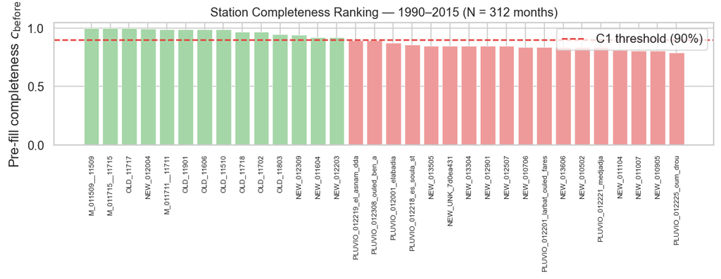

```
Saved: 01_completeness_ranking.png
```

```python
# ── 3.2  Completeness histogram ────────────────────────────────────────────────
fig, ax = plt.subplots(figsize=(10, 4))
bins = np.linspace(0, 1, 21)
colors = ["#EF9A9A" if v < 0.90 else "#A5D6A7" for v in completeness["c_before"]]
ax.bar(completeness.index, completeness["c_before"], color=colors,
       edgecolor="white", linewidth=0.4, width=0.8)
ax.axhline(C1_THRESHOLD, color="#E53935", linestyle="--", linewidth=1.5,
           label=f"C1 threshold ({C1_THRESHOLD:.0%})")
ax.set_xticks(completeness.index)
ax.set_xticklabels(completeness[STATION_COL], rotation=90, fontsize=7)
ax.set_ylabel("Pre-fill completeness $c_{\mathrm{before}}$")
ax.set_ylim(0, 1.05)
ax.set_title("Station Completeness Ranking — 1990–2015 (N = 312 months)", fontsize=12)
ax.legend()
plt.tight_layout()
fig.savefig(OUTPUT_DIR / "01_completeness_ranking.png", dpi=150, bbox_inches="tight")
plt.show()
print("Saved: 01_completeness_ranking.png")
```

## Section 4 — Station Selection

Three conjunctive eligibility conditions are applied sequentially. A station must satisfy **all three** to enter the final analytical panel.

### Condition C1 — Minimum pre-fill completeness

$$c_{\text{before}}(i) \geq 0.90$$

**Why 90 %?** The 90 % threshold is an **operational modeling choice** selected to balance data quality and sample size, and is consistent with common practices in hydrological time-series preprocessing. It ensures that the imputed fraction of any retained station's series remains at most 10 % — the level beyond which Gamma distribution parameter estimates *may become less stable*, since imputed values contribute to the empirical distribution used for fitting. A lower threshold would admit stations where imputed values begin to dominate the tails of the empirical distribution, which *can introduce bias* into SPI extremes. A higher threshold would unnecessarily reduce spatial coverage of the panel.

This is a deliberate trade-off: spatial density is sacrificed in exchange for reducing dependence on imputed values in the statistical fitting step.

### Condition C2 — Maximum contiguous gap

$$g_{\max}(i) \leq 3 \text{ months}$$

The 3-month ceiling is likewise an **operational modeling choice** that is consistent with common practice in hydrological preprocessing. A gap of 1–3 months in a monthly precipitation record can reasonably be bridged by linear interpolation, under the assumption that the true value varies smoothly between the adjacent observed months. Gaps of 4 or more consecutive months span entire seasons, making this smooth-variation assumption increasingly difficult to justify — the interpolated values *may* misrepresent the seasonal cycle and *could* introduce artificial structure into the SPI series.

Stations with gaps > 3 months are therefore excluded from the analytical panel. This decision was therefore incorporated into the station selection stage before any interpolation is applied, ensuring that the interpolation step operates only on gaps that satisfy the continuity assumption.

### Condition C3 — Manual exclusion

Station `M_011509__11509` satisfies C1 and C2 but is manually excluded under C3. Manual exclusions are reserved for stations where a quantitative anomaly cannot be resolved by completeness or gap criteria alone — typically where the record structure suggests a non-climatic data problem that would silently contaminate the index construction.

#### Justification of manual exclusions (C3)

The following table documents every manual exclusion, its objective basis, and the consequence if the station were retained without correction.

[output not shown]

All manual exclusions are logged here and in `station_selection_table.csv` with a `C3_excluded = True` flag, ensuring the decision is fully traceable and not silently embedded in the code.

```python
# ── 4.1  Compute max contiguous gap per station ───────────────────────────────
def max_contiguous_gap(series: pd.Series) -> int:
    """Return the length of the longest run of NaN values."""
    max_gap = cur = 0
    for v in series:
        if pd.isna(v): cur += 1; max_gap = max(max_gap, cur)
        else: cur = 0
    return max_gap

gap_stats = (
    precip_window
    .sort_values([STATION_COL, DATE_COL])
    .groupby(STATION_COL)[PRECIP_COL]
    .apply(max_contiguous_gap)
    .rename("max_gap")
    .reset_index()
)

# Merge with completeness
station_eligibility = completeness.merge(gap_stats, on=STATION_COL)

# Apply conditions
station_eligibility["C1"] = station_eligibility["c_before"] >= C1_THRESHOLD
station_eligibility["C2"] = station_eligibility["max_gap"] <= C2_MAX_GAP

# C3 — manual exclusion (documented in thesis Section 1.6.2)
C3_EXCLUDED = ["M_011509__11509"]
station_eligibility["C3_excluded"] = station_eligibility[STATION_COL].isin(C3_EXCLUDED)
station_eligibility["eligible"] = (
    station_eligibility["C1"] &
    station_eligibility["C2"] &
    ~station_eligibility["C3_excluded"]
)

# Summary
n_C1       = station_eligibility["C1"].sum()
n_C1_C2    = (station_eligibility["C1"] & station_eligibility["C2"]).sum()
n_final    = station_eligibility["eligible"].sum()
n_excluded_C3 = station_eligibility["C3_excluded"].sum()

print("Station selection funnel:")
print(f"  Total stations in window:          32")
print(f"  Pass C1  (c_before ≥ {C1_THRESHOLD:.0%}):           {n_C1:2d}")
print(f"  Pass C1 ∩ C2  (max_gap ≤ {C2_MAX_GAP} mo):     {n_C1_C2:2d}")
print(f"  Manually excluded (C3):             {n_excluded_C3:2d}  →  {C3_EXCLUDED}")
print(f"  ─────────────────────────────────────────")
print(f"  Final analytical panel:            {n_final:2d} stations")
```

```
Station selection funnel:
  Total stations in window:          32
  Pass C1  (c_before ≥ 90%):           14
  Pass C1 ∩ C2  (max_gap ≤ 3 mo):     10
  Manually excluded (C3):              1  →  ['M_011509__11509']
  ─────────────────────────────────────────
  Final analytical panel:             9 stations
```

```python
# ── 4.2  Eligibility table ────────────────────────────────────────────────────
display_cols = [STATION_COL, "n_obs", "n_missing", "c_before",
                "max_gap", "C1", "C2", "C3_excluded", "eligible"]

def style_eligibility(df):
    def row_color(row):
        if row["eligible"]:
            return ["background-color: #E8F5E9"] * len(row)
        elif row["C3_excluded"]:
            return ["background-color: #FFF9C4"] * len(row)
        return [""] * len(row)
    return (
        df[display_cols].style
        .apply(row_color, axis=1)
        .format({"c_before": "{:.3f}", "missing_pct": "{:.1f}"})
        .set_caption(
            "Station eligibility assessment (1990–2015). "
            "Green: retained in final panel. Yellow: C3 manual exclusion. "
            "White: failed C1 or C2."
        )
    )

display(style_eligibility(station_eligibility.sort_values("c_before", ascending=False)))
```

Station eligibility assessment (1990–2015). Green: retained in final panel. Yellow: C3 manual exclusion. White: failed C1 or C2.

|  | master_station_id | n_obs | n_missing | c_before | max_gap | C1 | C2 | C3_excluded | eligible |
| --- | --- | --- | --- | --- | --- | --- | --- | --- | --- |
| 0 | M_011509__11509 | 312 | 0 | 1.000 | 0 | True | True | True | False |
| 1 | M_011715__11715 | 312 | 0 | 1.000 | 0 | True | True | False | True |
| 2 | OLD_11717 | 312 | 0 | 1.000 | 0 | True | True | False | True |
| 3 | NEW_012004 | 310 | 2 | 0.994 | 1 | True | True | False | True |
| 4 | M_011711__11711 | 309 | 3 | 0.990 | 3 | True | True | False | True |
| 5 | OLD_11901 | 308 | 4 | 0.987 | 2 | True | True | False | True |
| 6 | OLD_11606 | 308 | 4 | 0.987 | 1 | True | True | False | True |
| 7 | OLD_11510 | 308 | 4 | 0.987 | 2 | True | True | False | True |
| 8 | OLD_11718 | 303 | 9 | 0.971 | 1 | True | True | False | True |
| 9 | OLD_11702 | 302 | 10 | 0.968 | 3 | True | True | False | True |
| 10 | OLD_11803 | 296 | 16 | 0.949 | 5 | True | False | False | False |
| 11 | NEW_012309 | 294 | 18 | 0.942 | 16 | True | False | False | False |
| 12 | NEW_011604 | 287 | 25 | 0.920 | 24 | True | False | False | False |
| 13 | NEW_012203 | 287 | 25 | 0.920 | 24 | True | False | False | False |
| 14 | PLUVIO_012219_el_asnam_dda | 280 | 32 | 0.897 | 28 | False | False | False | False |
| 15 | PLUVIO_012308_ouled_ben_a | 280 | 32 | 0.897 | 28 | False | False | False | False |
| 16 | PLUVIO_012001_elabadia | 273 | 39 | 0.875 | 28 | False | False | False | False |
| 17 | PLUVIO_012218_es_soula_st | 268 | 44 | 0.859 | 35 | False | False | False | False |
| 18 | NEW_013505 | 264 | 48 | 0.846 | 48 | False | False | False | False |
| 19 | NEW_UNK_7d0ea431 | 264 | 48 | 0.846 | 48 | False | False | False | False |
| 20 | NEW_013304 | 264 | 48 | 0.846 | 48 | False | False | False | False |
| 21 | NEW_012901 | 264 | 48 | 0.846 | 48 | False | False | False | False |
| 22 | NEW_012507 | 264 | 48 | 0.846 | 48 | False | False | False | False |
| 23 | NEW_010706 | 262 | 50 | 0.840 | 48 | False | False | False | False |
| 24 | PLUVIO_012201_larbat_ouled_fares | 262 | 50 | 0.840 | 31 | False | False | False | False |
| 25 | NEW_013606 | 262 | 50 | 0.840 | 48 | False | False | False | False |
| 26 | NEW_010502 | 261 | 51 | 0.837 | 48 | False | False | False | False |
| 27 | PLUVIO_012221_medjadja | 261 | 51 | 0.837 | 28 | False | False | False | False |
| 28 | NEW_011104 | 253 | 59 | 0.811 | 48 | False | False | False | False |
| 29 | NEW_011007 | 252 | 60 | 0.808 | 48 | False | False | False | False |
| 30 | NEW_010905 | 251 | 61 | 0.804 | 48 | False | False | False | False |
| 31 | PLUVIO_012225_oum_drou | 246 | 66 | 0.788 | 28 | False | False | False | False |

```python
# ── 4.3  Declare the final station list ───────────────────────────────────────
RETAINED_STATIONS = (
    station_eligibility[station_eligibility["eligible"]][STATION_COL]
    .sort_values()
    .tolist()
)
print(f"Retained stations ({len(RETAINED_STATIONS)}):")
for sid in RETAINED_STATIONS:
    row = station_eligibility[station_eligibility[STATION_COL] == sid].iloc[0]
    print(f"  {sid:35s}  c={row['c_before']:.3f}  n_miss={int(row['n_missing']):2d}  max_gap={int(row['max_gap'])}")
```

```
Retained stations (9):
  M_011711__11711                      c=0.990  n_miss= 3  max_gap=3
  M_011715__11715                      c=1.000  n_miss= 0  max_gap=0
  NEW_012004                           c=0.994  n_miss= 2  max_gap=1
  OLD_11510                            c=0.987  n_miss= 4  max_gap=2
  OLD_11606                            c=0.987  n_miss= 4  max_gap=1
  OLD_11702                            c=0.968  n_miss=10  max_gap=3
  OLD_11717                            c=1.000  n_miss= 0  max_gap=0
  OLD_11718                            c=0.971  n_miss= 9  max_gap=1
  OLD_11901                            c=0.987  n_miss= 4  max_gap=2
```

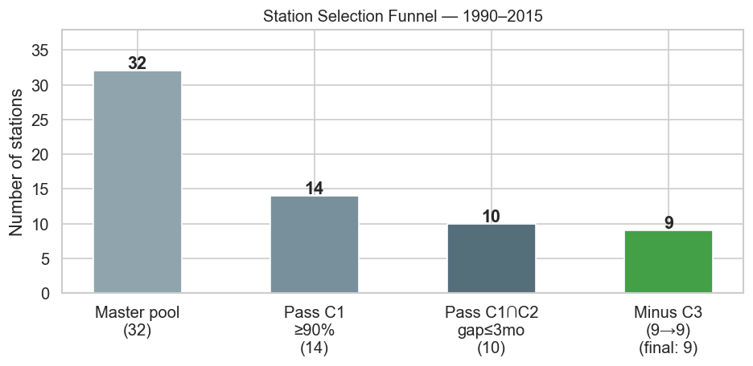

```
Saved: 01_station_selection_funnel.png
```

```python
# ── 4.4  Reduction funnel bar chart ───────────────────────────────────────────
fig, ax = plt.subplots(figsize=(8, 4))
stages = ["Master pool\n(32)", f"Pass C1\n≥{C1_THRESHOLD:.0%}\n({n_C1})",
          f"Pass C1∩C2\ngap≤{C2_MAX_GAP}mo\n({n_C1_C2})",
          f"Minus C3\n({n_C1_C2-n_excluded_C3}→{n_final})\n(final: {n_final})"]
counts = [32, n_C1, n_C1_C2, n_final]
bar_colors = ["#90A4AE", "#78909C", "#546E7A", "#43A047"]
bars = ax.bar(stages, counts, color=bar_colors, width=0.5, edgecolor="white")
for bar, v in zip(bars, counts):
    ax.text(bar.get_x() + bar.get_width()/2, bar.get_height() + 0.3,
            str(v), ha="center", fontsize=13, fontweight="bold")
ax.set_ylabel("Number of stations")
ax.set_title("Station Selection Funnel — 1990–2015", fontsize=12)
ax.set_ylim(0, 38)
plt.tight_layout()
fig.savefig(OUTPUT_DIR / "01_station_selection_funnel.png", dpi=150, bbox_inches="tight")
plt.show()
print("Saved: 01_station_selection_funnel.png")
```

## Section 5 — Missing Data Structure (Retained Stations)

Having identified the retained station set, we now characterise the missing data structure **only within that set**. This is the missing data that the interpolation step must resolve.

Two complementary views are produced:

1. **Temporal distribution** — do missing values cluster in particular years or decades? Clustering would suggest systematic archive failures (e.g., administrative disruptions) rather than random instrument outages.
2. **Station-level distribution** — which stations carry most of the interpolation burden?

```python
# ── 5.1  Filter to retained stations ─────────────────────────────────────────
precip_retained = precip_window[
    precip_window[STATION_COL].isin(RETAINED_STATIONS)
].copy()

total_cells    = len(precip_retained)
total_missing  = precip_retained[PRECIP_COL].isna().sum()
missing_frac   = total_missing / total_cells

print(f"Retained panel: {len(RETAINED_STATIONS)} stations × {N_MONTHS} months = {total_cells:,} cells")
print(f"Missing before interpolation: {total_missing} ({100*missing_frac:.2f}%)")
print(f"Present before interpolation: {total_cells - total_missing} ({100*(1-missing_frac):.2f}%)")
```

```
Retained panel: 9 stations × 312 months = 2,808 cells
Missing before interpolation: 36 (1.28%)
Present before interpolation: 2772 (98.72%)
```

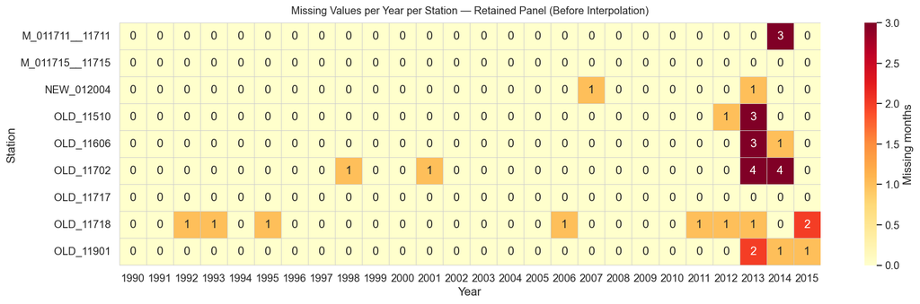

```
Saved: 01_missing_heatmap_retained.png
```

```python
# ── 5.2  Annual missing count heatmap ─────────────────────────────────────────
precip_retained = precip_retained.copy()
precip_retained["year"] = precip_retained[DATE_COL].dt.year

miss_heatmap = (
    precip_retained
    .assign(is_missing=precip_retained[PRECIP_COL].isna().astype(int))
    .groupby(["year", STATION_COL])["is_missing"]
    .sum()
    .unstack(fill_value=0)
)

fig, ax = plt.subplots(figsize=(16, max(5, len(RETAINED_STATIONS) * 0.55)))
sns.heatmap(
    miss_heatmap.T,
    ax=ax, cmap="YlOrRd",
    linewidths=0.3, linecolor="#cccccc",
    annot=True, fmt="d",
    cbar_kws={"label": "Missing months"},
    vmin=0, vmax=3,
)
ax.set_title(
    "Missing Values per Year per Station — Retained Panel (Before Interpolation)",
    fontsize=12, pad=10
)
ax.set_xlabel("Year")
ax.set_ylabel("Station")
plt.tight_layout()
fig.savefig(OUTPUT_DIR / "01_missing_heatmap_retained.png", dpi=150, bbox_inches="tight")
plt.show()
print("Saved: 01_missing_heatmap_retained.png")
```

## Section 6 — Gap Analysis

A **gap** is a contiguous sequence of one or more missing months within a station's record. The gap length determines whether linear interpolation is applicable.

For each station, we enumerate all gaps, record their start date and length, and classify them as:

- **Fillable** (length ≤ 3 months): eligible for linear interpolation
- **Unfillable** (length > 3 months): must remain as NaN (no station in the retained panel has such gaps — this was enforced by Condition C2)

This section produces the full gap inventory that drives the interpolation logic in Section 8.

```python
# ── 6.1  Enumerate all gaps per station ───────────────────────────────────────
def enumerate_gaps(group: pd.DataFrame) -> pd.DataFrame:
    """Return a DataFrame of all contiguous NaN runs in a station's series."""
    sid      = group[STATION_COL].iloc[0]
    dates    = group[DATE_COL].values
    vals     = group[PRECIP_COL].values
    records  = []
    cur_start_idx = None
    for i, v in enumerate(vals):
        if pd.isna(v):
            if cur_start_idx is None:
                cur_start_idx = i
        else:
            if cur_start_idx is not None:
                length = i - cur_start_idx
                records.append({
                    STATION_COL:   sid,
                    "gap_start":   pd.Timestamp(dates[cur_start_idx]),
                    "gap_end":     pd.Timestamp(dates[i - 1]),
                    "gap_length":  length,
                    "fillable":    length <= INTERP_MAX_GAP,
                })
                cur_start_idx = None
    # Handle gap at end of series
    if cur_start_idx is not None:
        length = len(vals) - cur_start_idx
        records.append({
            STATION_COL: sid,
            "gap_start":  pd.Timestamp(dates[cur_start_idx]),
            "gap_end":    pd.Timestamp(dates[-1]),
            "gap_length": length,
            "fillable":   length <= INTERP_MAX_GAP,
        })
    return pd.DataFrame(records)

gap_inventory = pd.concat([
    enumerate_gaps(grp.sort_values(DATE_COL))
    for _, grp in precip_retained.groupby(STATION_COL)
], ignore_index=True)

print(f"Total gaps detected: {len(gap_inventory)}")
print(f"  Fillable   (length ≤ {INTERP_MAX_GAP}): {gap_inventory['fillable'].sum()}")
print(f"  Unfillable (length > {INTERP_MAX_GAP}): {(~gap_inventory['fillable']).sum()}")
print()
print("Gap length frequency distribution:")
print(gap_inventory.groupby(["gap_length", "fillable"]).size()
      .reset_index(name="count").to_string(index=False))
```

```
Total gaps detected: 29
  Fillable   (length ≤ 3): 29
  Unfillable (length > 3): 0

Gap length frequency distribution:
 gap_length  fillable  count
          1      True     24
          2      True      3
          3      True      2
```

```python
# ── 6.2  Gap inventory table ──────────────────────────────────────────────────
print("Full gap inventory (all retained stations):")
display(
    gap_inventory.sort_values([STATION_COL, "gap_start"])
    .style
    .applymap(lambda v: "color: #C62828" if not v else "color: #2E7D32",
              subset=["fillable"])
    .format({"gap_start": lambda x: x.strftime("%Y-%m"),
             "gap_end":   lambda x: x.strftime("%Y-%m")})
    .set_caption("Gap inventory for retained stations. "
                 "Green = fillable (≤ 3 mo). Red = unfillable (> 3 mo).")
)
```

```
Full gap inventory (all retained stations):
```

Gap inventory for retained stations. Green = fillable (≤ 3 mo). Red = unfillable (> 3 mo).

|  | master_station_id | gap_start | gap_end | gap_length | fillable |
| --- | --- | --- | --- | --- | --- |
| 0 | M_011711__11711 | 2014-09 | 2014-11 | 3 | True |
| 1 | NEW_012004 | 2007-11 | 2007-11 | 1 | True |
| 2 | NEW_012004 | 2013-08 | 2013-08 | 1 | True |
| 3 | OLD_11510 | 2012-06 | 2012-06 | 1 | True |
| 4 | OLD_11510 | 2013-07 | 2013-08 | 2 | True |
| 5 | OLD_11510 | 2013-10 | 2013-10 | 1 | True |
| 6 | OLD_11606 | 2013-06 | 2013-06 | 1 | True |
| 7 | OLD_11606 | 2013-08 | 2013-08 | 1 | True |
| 8 | OLD_11606 | 2013-10 | 2013-10 | 1 | True |
| 9 | OLD_11606 | 2014-04 | 2014-04 | 1 | True |
| 10 | OLD_11702 | 1998-08 | 1998-08 | 1 | True |
| 11 | OLD_11702 | 2001-08 | 2001-08 | 1 | True |
| 12 | OLD_11702 | 2013-07 | 2013-09 | 3 | True |
| 13 | OLD_11702 | 2013-12 | 2013-12 | 1 | True |
| 14 | OLD_11702 | 2014-04 | 2014-04 | 1 | True |
| 15 | OLD_11702 | 2014-06 | 2014-07 | 2 | True |
| 16 | OLD_11702 | 2014-12 | 2014-12 | 1 | True |
| 17 | OLD_11718 | 1992-09 | 1992-09 | 1 | True |
| 18 | OLD_11718 | 1993-07 | 1993-07 | 1 | True |
| 19 | OLD_11718 | 1995-08 | 1995-08 | 1 | True |
| 20 | OLD_11718 | 2006-07 | 2006-07 | 1 | True |
| 21 | OLD_11718 | 2011-08 | 2011-08 | 1 | True |
| 22 | OLD_11718 | 2012-07 | 2012-07 | 1 | True |
| 23 | OLD_11718 | 2013-08 | 2013-08 | 1 | True |
| 24 | OLD_11718 | 2015-08 | 2015-08 | 1 | True |
| 25 | OLD_11718 | 2015-12 | 2015-12 | 1 | True |
| 26 | OLD_11901 | 2013-07 | 2013-08 | 2 | True |
| 27 | OLD_11901 | 2014-08 | 2014-08 | 1 | True |
| 28 | OLD_11901 | 2015-08 | 2015-08 | 1 | True |

## Section 7 — Definition of the Interpolation Rule

### Rule

Linear interpolation is applied **if and only if** the contiguous gap length satisfies:

$$g \leq 3 \text{ months}$$

Formally, for a missing observation at month $t$ within a gap of length $g$ bounded by observed values $P_{t-1}$ (last observed before the gap) and $P_{t+g}$ (first observed after the gap):

$$\hat{P}_{t+k} = P_{t-1} + (k+1) \cdot \frac{P_{t+g} - P_{t-1}}{g+1} \qquad k = 0, 1, \ldots, g-1$$

### Why linear interpolation?

Monthly precipitation does not exhibit strong nonlinear short-term structure (unlike temperature, which may have quadratic or exponential components). Linear interpolation is the simplest defensible choice under the assumption that the true value varies smoothly between the two adjacent observations. It introduces no distributional assumptions beyond local continuity, is fully deterministic, and is a standard approach in the SPI literature (Guttman, 1999; McKee et al., 1993).

### Why the 3-month ceiling?

The 3-month ceiling is an **operational modeling choice** that was incorporated at the station-selection stage (Condition C2), not enforced solely by the interpolation procedure itself. By excluding stations with gaps > 3 months before any interpolation is applied, we ensure that the interpolation step operates exclusively on gaps that satisfy the smooth-variation assumption implicit in linear estimation. The `limit` parameter of `pandas.Series.interpolate` is used as a **secondary programmatic safeguard** — an additional layer of protection against accidental application to longer gaps — but the primary guarantee is structural: no retained station can have a gap exceeding 3 months, because such stations were excluded under C2.

Substantive justification for the 3-month limit:

- **Gap of 1 month**: the interpolated value lies between two adjacent monthly totals, both observed. The estimate is well-constrained and the interpolation error is bounded by the month-to-month variability.
- **Gap of 2 months**: spans at most ~60 days; linear interpolation introduces at most one intermediate seasonal step, which remains reasonable for accumulation-based indices.
- **Gap of 3 months**: the maximum gap where the interpolation can be argued to remain within a single seasonal quadrant (e.g., entirely within the wet season or entirely within the dry season). Beyond 3 months, the linear path crosses season boundaries and the imputed values *may be systematically biased* relative to the true seasonal climatology.

### Why not impute larger gaps?

Gaps of 4 or more months span entire seasons. Applying linear interpolation across such gaps would:

1. *Risk misrepresenting* the seasonal precipitation distribution and thereby *potentially biasing* the per-month Gamma fits on which SPI depends.
2. *Potentially introduce* artificial smoothness at the gap boundaries, which could inflate the apparent autocorrelation of the series.
3. Inflate the effective number of observations for calendar months where the record is structurally absent, undermining the validity of the fitted distribution for those months.

For these reasons, the interpolation burden was *deliberately minimised* — applied only where the structural and seasonal continuity assumptions are most defensible.

## Section 8 — Apply Controlled Linear Interpolation

The interpolation is applied **per station** using `pandas.Series.interpolate` with `method='linear'` and `limit=INTERP_MAX_GAP`. As established in Section 7, the primary guarantee that no gap exceeding 3 months is filled comes from the station-selection stage (Condition C2): all retained stations have maximum contiguous gaps ≤ 3 months by construction. The `limit` parameter serves as an **additional programmatic safeguard** to make this constraint explicit in the interpolation call and to protect against any edge case that might arise from data manipulation between sections.

A boolean column `was_interpolated` is created to flag every value that was imputed by this step. This column is preserved in all downstream outputs, ensuring that any analysis can identify and optionally downweight imputed observations.

**Column conventions:**

- `precip_mm` — raw observed precipitation, preserved unchanged (NaN where missing in source archives)
- `precip_filled` — the series used for SPI computation; identical to `precip_mm` for observed months, linearly interpolated for gap months
- `was_interpolated` — `True` only for months where `precip_mm` is NaN and `precip_filled` was estimated by interpolation

All transformations are explicitly tracked, ensuring full reproducibility and transparency of the preprocessing steps.

```python
# ── 8.1  Apply interpolation and track imputed values ────────────────────────
precip_interp = precip_retained.copy()

# Initialise tracking columns
precip_interp["precip_filled"]    = precip_interp[PRECIP_COL].copy()
precip_interp["was_interpolated"] = False

for sid, grp in precip_interp.groupby(STATION_COL):
    idx = grp.index.tolist()

    # pandas interpolate: linear, fill gaps ≤ INTERP_MAX_GAP only
    filled = (
        grp["precip_filled"]
        .interpolate(method="linear", limit=INTERP_MAX_GAP, limit_direction="forward")
    )

    # Identify which values changed (were NaN before, not NaN after)
    was_missing_before = grp[PRECIP_COL].isna()
    is_filled_after    = filled.notna()
    interp_mask        = was_missing_before & is_filled_after

    precip_interp.loc[idx, "precip_filled"]    = filled.values
    precip_interp.loc[idx, "was_interpolated"] = interp_mask.values

n_interp = precip_interp["was_interpolated"].sum()
n_still_missing = precip_interp["precip_filled"].isna().sum()
total = len(precip_interp)

print(f"Interpolation results:")
print(f"  Values interpolated:    {n_interp:3d}  ({100*n_interp/total:.3f}% of panel)")
print(f"  Still missing (NaN):    {n_still_missing:3d}  (should be 0 — C2 guarantee)")
print(f"  Fully observed:         {total - n_interp:3d}  ({100*(total-n_interp)/total:.3f}%)")

if n_still_missing > 0:
    print("\n⚠ WARNING: residual missing values detected — check C2 condition enforcement.")
else:
    print("\n✓ All gaps within the retained panel have been filled.")
```

```
Interpolation results:
  Values interpolated:     36  (1.282% of panel)
  Still missing (NaN):      0  (should be 0 — C2 guarantee)
  Fully observed:         2772  (98.718%)

✓ All gaps within the retained panel have been filled.
```

```python
# ── 8.2  Verify non-negativity of interpolated values ─────────────────────────
neg_after_interp = (precip_interp["precip_filled"] < 0).sum()
print(f"Negative values in precip_filled: {neg_after_interp}")
if neg_after_interp > 0:
    neg_rows = precip_interp[precip_interp["precip_filled"] < 0]
    display(neg_rows[[STATION_COL, DATE_COL, PRECIP_COL, "precip_filled", "was_interpolated"]])
    print("ACTION REQUIRED: clamp to 0 or investigate source.")
else:
    print("✓ All interpolated values are non-negative.")
```

```
Negative values in precip_filled: 0
✓ All interpolated values are non-negative.
```

## Section 9 — Post-Interpolation Validation

For each retained station, we report:

- **n_interp**: number of months imputed by linear interpolation
- **pct_interp**: imputed fraction of the 312-month record
- **c_after**: post-fill completeness (expected to equal 1.000 for all stations, since the C2 condition guarantees all gaps are fillable)

```python
# ── 9.1  Per-station interpolation summary ────────────────────────────────────
interp_summary = (
    precip_interp
    .groupby(STATION_COL)
    .apply(lambda g: pd.Series({
        "n_obs_raw":    int(g[PRECIP_COL].notna().sum()),
        "n_interp":     int(g["was_interpolated"].sum()),
        "n_missing_post": int(g["precip_filled"].isna().sum()),
        "c_before":     g[PRECIP_COL].notna().sum() / N_MONTHS,
        "c_after":      g["precip_filled"].notna().sum() / N_MONTHS,
        "pct_interp":   100 * g["was_interpolated"].sum() / N_MONTHS,
    }))
    .reset_index()
    .sort_values("pct_interp", ascending=False)
)

# Aggregate row
agg_row = pd.DataFrame([{
    STATION_COL:     "─── AGGREGATE ───",
    "n_obs_raw":     interp_summary["n_obs_raw"].sum(),
    "n_interp":      interp_summary["n_interp"].sum(),
    "n_missing_post": interp_summary["n_missing_post"].sum(),
    "c_before":      interp_summary["n_obs_raw"].sum() / (N_MONTHS * len(RETAINED_STATIONS)),
    "c_after":       (interp_summary["n_obs_raw"].sum() + interp_summary["n_interp"].sum())
                     / (N_MONTHS * len(RETAINED_STATIONS)),
    "pct_interp":    100 * interp_summary["n_interp"].sum()
                     / (N_MONTHS * len(RETAINED_STATIONS)),
}])
interp_summary_display = pd.concat([interp_summary, agg_row], ignore_index=True)

print("Post-interpolation station summary:")
display(
    interp_summary_display.style
    .format({
        "c_before": "{:.3f}", "c_after": "{:.3f}", "pct_interp": "{:.3f}%"
    })
    .applymap(lambda v: "color: #C62828; font-weight: bold" if isinstance(v, float) and v < 1.0
              else "", subset=["c_after"])
    .set_caption(
        "Interpolation burden per station. c_after = 1.000 for all retained stations "
        "confirms that the C2 constraint guarantees complete gap-filling. "
        "pct_interp is the fraction of the 312-month record that was imputed."
    )
)
```

```
Post-interpolation station summary:
```

Interpolation burden per station. c_after = 1.000 for all retained stations confirms that the C2 constraint guarantees complete gap-filling. pct_interp is the fraction of the 312-month record that was imputed.

|  | master_station_id | n_obs_raw | n_interp | n_missing_post | c_before | c_after | pct_interp |
| --- | --- | --- | --- | --- | --- | --- | --- |
| 0 | OLD_11702 | 302.000000 | 10.000000 | 0.000000 | 0.968 | 1.000 | 3.205% |
| 1 | OLD_11718 | 303.000000 | 9.000000 | 0.000000 | 0.971 | 1.000 | 2.885% |
| 2 | OLD_11510 | 308.000000 | 4.000000 | 0.000000 | 0.987 | 1.000 | 1.282% |
| 3 | OLD_11606 | 308.000000 | 4.000000 | 0.000000 | 0.987 | 1.000 | 1.282% |
| 4 | OLD_11901 | 308.000000 | 4.000000 | 0.000000 | 0.987 | 1.000 | 1.282% |
| 5 | M_011711__11711 | 309.000000 | 3.000000 | 0.000000 | 0.990 | 1.000 | 0.962% |
| 6 | NEW_012004 | 310.000000 | 2.000000 | 0.000000 | 0.994 | 1.000 | 0.641% |
| 7 | M_011715__11715 | 312.000000 | 0.000000 | 0.000000 | 1.000 | 1.000 | 0.000% |
| 8 | OLD_11717 | 312.000000 | 0.000000 | 0.000000 | 1.000 | 1.000 | 0.000% |
| 9 | ─── AGGREGATE ─── | 2772.000000 | 36.000000 | 0.000000 | 0.987 | 1.000 | 1.282% |

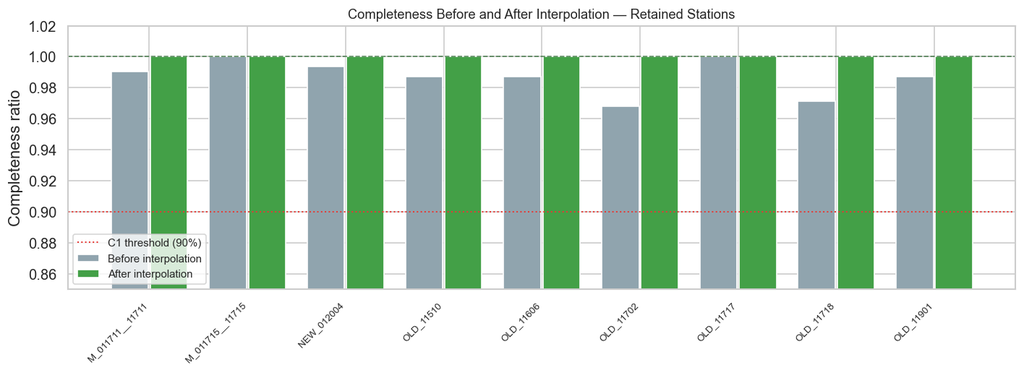

```
Saved: 01_completeness_before_after.png
```

```python
# ── 9.2  Figure: c_before vs c_after per station ──────────────────────────────
fig, ax = plt.subplots(figsize=(12, 4.5))
x = np.arange(len(RETAINED_STATIONS))
snames = interp_summary.sort_values(STATION_COL)[STATION_COL].tolist()
c_bef  = interp_summary.set_index(STATION_COL).loc[snames, "c_before"].values
c_aft  = interp_summary.set_index(STATION_COL).loc[snames, "c_after"].values

ax.bar(x - 0.2, c_bef, width=0.38, color="#90A4AE", label="Before interpolation")
ax.bar(x + 0.2, c_aft, width=0.38, color="#43A047", label="After interpolation")
ax.axhline(1.0, color="#1B5E20", linestyle="--", linewidth=1, alpha=0.7)
ax.axhline(C1_THRESHOLD, color="#E53935", linestyle=":", linewidth=1.2,
           label=f"C1 threshold ({C1_THRESHOLD:.0%})")
ax.set_xticks(x)
ax.set_xticklabels(snames, rotation=45, ha="right", fontsize=8)
ax.set_ylim(0.85, 1.02)
ax.set_ylabel("Completeness ratio")
ax.set_title("Completeness Before and After Interpolation — Retained Stations", fontsize=11)
ax.legend(fontsize=9)
plt.tight_layout()
fig.savefig(OUTPUT_DIR / "01_completeness_before_after.png", dpi=150, bbox_inches="tight")
plt.show()
print("Saved: 01_completeness_before_after.png")
```

## Section 10 — Interpolation Impact on Rolling Accumulation Windows

SPI at scale $k$ is computed from the $k$-month rolling sum:

$$X_t^{(k)} = \sum_{i=0}^{k-1} P_{t-i}$$

If one or more of the $k$ terms in this sum is an interpolated value, the accuracy of $X_t^{(k)}$ is reduced. In the worst case (a 3-month gap entirely within a 3-month window), SPI-3 would be computed entirely from interpolated values at that time step — the extreme case to be flagged and monitored.

For each time step and each station, we compute:

- `n_interp_in_window_3`: count of interpolated months in the SPI-3 window
- `n_interp_in_window_6`: count of interpolated months in the SPI-6 window
- `n_interp_in_window_12`: count of interpolated months in the SPI-12 window

This table allows downstream analysis to flag SPI values where the rolling sum contains a high imputed fraction.

```python
# ── 10.1  Compute rolling interpolation counts ────────────────────────────────
frames = []
for sid, grp in precip_interp.sort_values([STATION_COL, DATE_COL]).groupby(STATION_COL):
    g = grp.copy().reset_index(drop=True)
    interp_int = g["was_interpolated"].astype(int)
    g["n_interp_in_window_3"]  = interp_int.rolling(3,  min_periods=1).sum().astype(int)
    g["n_interp_in_window_6"]  = interp_int.rolling(6,  min_periods=1).sum().astype(int)
    g["n_interp_in_window_12"] = interp_int.rolling(12, min_periods=1).sum().astype(int)
    frames.append(g)
precip_interp = pd.concat(frames, ignore_index=True)

# Summary: how many time steps have ≥1 interpolated value in each window?
for k, col in [(3, "n_interp_in_window_3"), (6, "n_interp_in_window_6"),
               (12, "n_interp_in_window_12")]:
    n_affected = (precip_interp[col] >= 1).sum()
    n_total    = len(precip_interp)
    pct        = 100 * n_affected / n_total
    max_n      = precip_interp[col].max()
    print(f"SPI-{k:2d} window: {n_affected:5d} / {n_total} time-steps affected "
          f"({pct:.2f}%)  |  max interpolated in window: {max_n}")
```

```
SPI- 3 window:    88 / 2808 time-steps affected (3.13%)  |  max interpolated in window: 3
SPI- 6 window:   151 / 2808 time-steps affected (5.38%)  |  max interpolated in window: 4
SPI-12 window:   256 / 2808 time-steps affected (9.12%)  |  max interpolated in window: 6
```

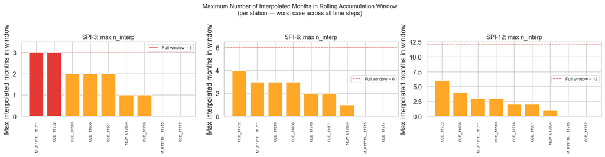

```
Saved: 01_rolling_window_interp_impact.png
```

```python
# ── 10.2  Figure: max interpolated count in window per station ────────────────
fig, axes = plt.subplots(1, 3, figsize=(16, 4))
for ax, k, col in zip(axes,
                      [3, 6, 12],
                      ["n_interp_in_window_3", "n_interp_in_window_6", "n_interp_in_window_12"]):
    max_by_station = precip_interp.groupby(STATION_COL)[col].max().sort_values(ascending=False)
    bar_colors = ["#E53935" if v >= k else "#43A047" if v == 0 else "#FFA726"
                  for v in max_by_station]
    ax.bar(range(len(max_by_station)), max_by_station.values,
           color=bar_colors, edgecolor="white")
    ax.set_xticks(range(len(max_by_station)))
    ax.set_xticklabels(max_by_station.index, rotation=90, fontsize=7)
    ax.set_ylabel("Max interpolated months in window")
    ax.set_title(f"SPI-{k}: max n_interp", fontsize=11)
    ax.set_ylim(0, k + 0.5)
    ax.axhline(k, color="#E53935", linestyle="--", linewidth=1,
               label=f"Full window = {k}")
    ax.legend(fontsize=8)
plt.suptitle(
    "Maximum Number of Interpolated Months in Rolling Accumulation Window\n"
    "(per station — worst case across all time steps)",
    fontsize=11, y=1.02
)
plt.tight_layout()
fig.savefig(OUTPUT_DIR / "01_rolling_window_interp_impact.png", dpi=150, bbox_inches="tight")
plt.show()
print("Saved: 01_rolling_window_interp_impact.png")
```

## Section 11 — Final Dataset Construction

The final dataset constitutes a **SPI-ready precipitation panel with controlled interpolation and explicit tracking of modified values**, containing one row per station-month across all retained stations over the 1990–2015 period. The schema is:

| Column | Type | Description |
| --- | --- | --- |
| `master_station_id` | str | Canonical station identifier |
| `date` | datetime | First day of the month (MS frequency) |
| `precip_mm` | float | Raw observed precipitation (NaN = missing in source archives) |
| `precip_filled` | float | Gap-filled precipitation used for SPI computation |
| `was_interpolated` | bool | True if this value was imputed by linear interpolation |
| `value_source` | str | Provenance flag from source archive |
| `source_dataset` | str | Archive of origin |
| `n_interp_in_window_3` | int | Interpolated months in SPI-3 accumulation window |
| `n_interp_in_window_6` | int | Interpolated months in SPI-6 accumulation window |
| `n_interp_in_window_12` | int | Interpolated months in SPI-12 accumulation window |

The `precip_filled` column is the input to notebook E.4 (SPI construction). The `precip_mm` column retains the raw observations unchanged. The `was_interpolated` flag allows notebook E.4 to identify and optionally report SPI values computed from windows containing imputed months. All transformations are explicitly tracked, ensuring full reproducibility and transparency of the preprocessing steps.

```python
# ── 11.1  Assemble final dataset ──────────────────────────────────────────────
FINAL_COLS = [
    STATION_COL, DATE_COL,
    PRECIP_COL,                  # raw (with NaN where missing)
    "precip_filled",             # gap-filled (complete, no NaN)
    "was_interpolated",          # provenance flag
    "value_source", "source_dataset",
    "n_interp_in_window_3",
    "n_interp_in_window_6",
    "n_interp_in_window_12",
]

final_df = (
    precip_interp[FINAL_COLS]
    .sort_values([STATION_COL, DATE_COL])
    .reset_index(drop=True)
)

print(f"Final dataset shape: {final_df.shape}")
print(f"  Stations:          {final_df[STATION_COL].nunique()}")
print(f"  Months per station: {N_MONTHS}")
print(f"  Total cells:       {len(final_df)}")
print(f"  Interpolated rows: {final_df['was_interpolated'].sum()}")
print(f"  Missing (precip_filled): {final_df['precip_filled'].isna().sum()}")
print()
final_df.head(6)
```

```
Final dataset shape: (2808, 10)
  Stations:          9
  Months per station: 312
  Total cells:       2808
  Interpolated rows: 36
  Missing (precip_filled): 0
```

|  | master_station_id | date | precip_mm | precip_filled | was_interpolated | value_source | source_dataset | n_interp_in_window_3 | n_interp_in_window_6 | n_interp_in_window_12 |
| --- | --- | --- | --- | --- | --- | --- | --- | --- | --- | --- |
| 0 | M_011711__11711 | 1990-01-01 | 62.6000 | 62.6000 | False | reconciled_prefer_old | merged_pair | 0 | 0 | 0 |
| 1 | M_011711__11711 | 1990-02-01 | 60.1000 | 60.1000 | False | reconciled_prefer_old | merged_pair | 0 | 0 | 0 |
| 2 | M_011711__11711 | 1990-03-01 | 61.9000 | 61.9000 | False | reconciled_prefer_old | merged_pair | 0 | 0 | 0 |
| 3 | M_011711__11711 | 1990-04-01 | 21.3000 | 21.3000 | False | reconciled_prefer_old | merged_pair | 0 | 0 | 0 |
| 4 | M_011711__11711 | 1990-05-01 | 6.3000 | 6.3000 | False | reconciled_prefer_old | merged_pair | 0 | 0 | 0 |
| 5 | M_011711__11711 | 1990-06-01 | 6.4000 | 6.4000 | False | reconciled_prefer_old | merged_pair | 0 | 0 | 0 |

## Section 12 — Save Outputs

Three files are written to the notebook E.3 output folder.

| File | Content | Consumed by |
| --- | --- | --- |
| `spi_ready_dataset.csv` | SPI-ready panel with controlled interpolation | notebook E.4 (SPI construction) |
| `interpolation_summary.csv` | Per-station interpolation metrics | notebook E.4, Chapter 1 reporting |
| `station_selection_table.csv` | Full eligibility audit for all 32 stations | Chapter 1 reporting |

```python
# ── 12.1  Save final dataset ──────────────────────────────────────────────────
out_final = OUTPUT_DIR / "spi_ready_dataset.csv"
final_df.to_csv(out_final, index=False, date_format="%Y-%m-%d")
print(f"[1/3] Saved: {out_final.name}")
print(f"       Shape: {final_df.shape[0]:,} rows × {final_df.shape[1]} columns")

# ── 12.2  Save interpolation summary ─────────────────────────────────────────
out_interp = OUTPUT_DIR / "interpolation_summary.csv"
interp_summary.to_csv(out_interp, index=False)
print(f"[2/3] Saved: {out_interp.name}")

# ── 12.3  Save station selection table ───────────────────────────────────────
out_sel = OUTPUT_DIR / "station_selection_table.csv"
station_eligibility.to_csv(out_sel, index=False)
print(f"[3/3] Saved: {out_sel.name}")

print()
print(f"All outputs written to: {OUTPUT_DIR}")
```

```
[1/3] Saved: spi_ready_dataset.csv
       Shape: 2,808 rows × 10 columns
[2/3] Saved: interpolation_summary.csv
[3/3] Saved: station_selection_table.csv

All outputs written to: <project_root>\03_outputs\01_data_preprocessing_and_station_selection
```

## Section 13 — Final Validation

Six conditions are checked on the final dataset before it is handed to notebook E.4. Failure of any condition must be investigated and resolved before SPI computation proceeds.

```python
# ── 13.1  Six-point validation checklist ──────────────────────────────────────
checks = {}

# V1: No duplicate (station, date) pairs
dup_count = final_df.duplicated(subset=[STATION_COL, DATE_COL]).sum()
checks["V1 — No duplicate (station, date) pairs"] = (dup_count == 0, dup_count)

# V2: Consistent time index — all retained stations have exactly N_MONTHS rows
months_check = final_df.groupby(STATION_COL)[DATE_COL].count()
all_312 = (months_check == N_MONTHS).all()
offenders = months_check[months_check != N_MONTHS]
checks["V2 — All stations have exactly 312 monthly rows"] = (
    bool(all_312),
    f"{len(offenders)} stations differ: {offenders.to_dict()}" if len(offenders) else ""
)

# V3: No missing values in precip_filled
n_nan_filled = final_df["precip_filled"].isna().sum()
checks["V3 — No NaN in precip_filled"] = (n_nan_filled == 0, n_nan_filled)

# V4: All precip_filled values non-negative
n_neg = (final_df["precip_filled"] < 0).sum()
checks["V4 — All precip_filled ≥ 0"] = (n_neg == 0, n_neg)

# V5: was_interpolated count matches gap inventory
n_interp_final    = final_df["was_interpolated"].sum()
n_interp_expected = gap_inventory["gap_length"].sum()
checks["V5 — was_interpolated count matches gap inventory"] = (
    n_interp_final == n_interp_expected,
    f"final={n_interp_final}, expected={n_interp_expected}")

# V6: date frequency is strictly monthly (MS) for all stations
date_freq_ok = final_df.groupby(STATION_COL)[DATE_COL].apply(
    lambda x: (x.sort_values().diff().dropna().dt.days.between(28, 31)).all()
)
all_monthly = date_freq_ok.all()
checks["V6 — Strict monthly frequency in all stations"] = (bool(all_monthly), "")

# ── Print results ──────────────────────────────────────────────────────────────
print("Validation checklist:")
all_pass = True
for check_name, (passed, detail) in checks.items():
    status = "✓ PASS" if passed else "✗ FAIL"
    if not passed:
        all_pass = False
    detail_str = f"  ({detail})" if detail not in ("", 0) else ""
    print(f"  {status}  {check_name}{detail_str}")

print()
if all_pass:
    print("✓ All validation checks passed. Dataset is ready for SPI construction.")
else:
    print("✗ One or more validation checks failed. Investigate before proceeding.")
```

```
Validation checklist:
  ✓ PASS  V1 — No duplicate (station, date) pairs
  ✓ PASS  V2 — All stations have exactly 312 monthly rows
  ✓ PASS  V3 — No NaN in precip_filled
  ✓ PASS  V4 — All precip_filled ≥ 0
  ✓ PASS  V5 — was_interpolated count matches gap inventory  (final=36, expected=36)
  ✓ PASS  V6 — Strict monthly frequency in all stations

✓ All validation checks passed. Dataset is ready for SPI construction.
```

## Section 14 — Interpretation and Chapter Summary

### Why the scaffold expansion is methodologically necessary

The full grid produced by notebook E.2 extends each station only to its last observed date. Stations that stopped reporting before 2015-12-01 therefore had no rows — not NaN rows — for the trailing months of the study window. A simple date-range filter would have silently produced a structurally inconsistent panel (some stations with < 312 rows) and computed completeness ratios against an incorrect denominator. The scaffold expansion makes all absences **explicit NaN observations** before any eligibility computation is performed. This is a structural alignment step, not imputation.

### Final dataset summary

[output not shown]

The output file `spi_ready_dataset.csv` contains three parallel series for each station-month: `precip_mm` (raw), `precip_filled` (used for SPI), and `was_interpolated` (provenance flag). This structure ensures that the preprocessing chain is fully transparent and that any downstream analysis can assess the contribution of imputed values to its results.

> **Next step:** notebook E.4 (SPI construction and validation) reads `spi_ready_dataset.csv`, fits the two-parameter Gamma distribution separately for each station and each calendar month, computes SPI-3, SPI-6, and SPI-12, and validates the resulting series against the theoretical $\mathcal{N}(0,1)$ moments.